# Homework 1 Solutions

### b)

### _Solution: it is 17.9285 with rounding it is 18, similar to the part a.

```r
f2<-lm(y ~ x -1)
f2$coefficients
```

```
##       x
## 17.9285
```

Problem 3

Refer to the CDI data set. The number of active physicians in a CDI (Y) is expected to be related to total population, number of hospital beds, and total personal income. (30 points)

1. Regress the number of active physicians in turn on each of the three predictor variables. State the estimated regression functions. (10 points)
2. Plot the three estimated regression functions and data on separate graphs. Does a linear regression relation appear to provide a good fit for each of the three predictor variables? (10 points)
3. Calculate MSE for each of the three predictor variables. Which predictor variable leads to the smallest variability around the fitted regression line? Which variable would you use the estimate Y and why? (10 points) ### a) ### _Solution: see below

```r
CDI <- read.csv("/cloud/project/homework/CDI Data.csv")
Y=CDI$Number.of.active.physicians
X1=CDI$Total.population
X2=CDI$Number.of.hospital.beds
X3=CDI$Total.personal.income
f31<-lm(Y~X1)
f32<-lm(Y~X2)
f33<-lm(Y~X3)
rbind(f31$coefficients,f32$coefficients,f33$coefficients)
```

```
##      (Intercept)          X1
## [1,]  -110.63478 0.002795425
## [2,]   -95.93218 0.743116444
## [3,]   -48.39485 0.131701189
```

### b)

### _Solution: yes, there is a good fit for each of variables.

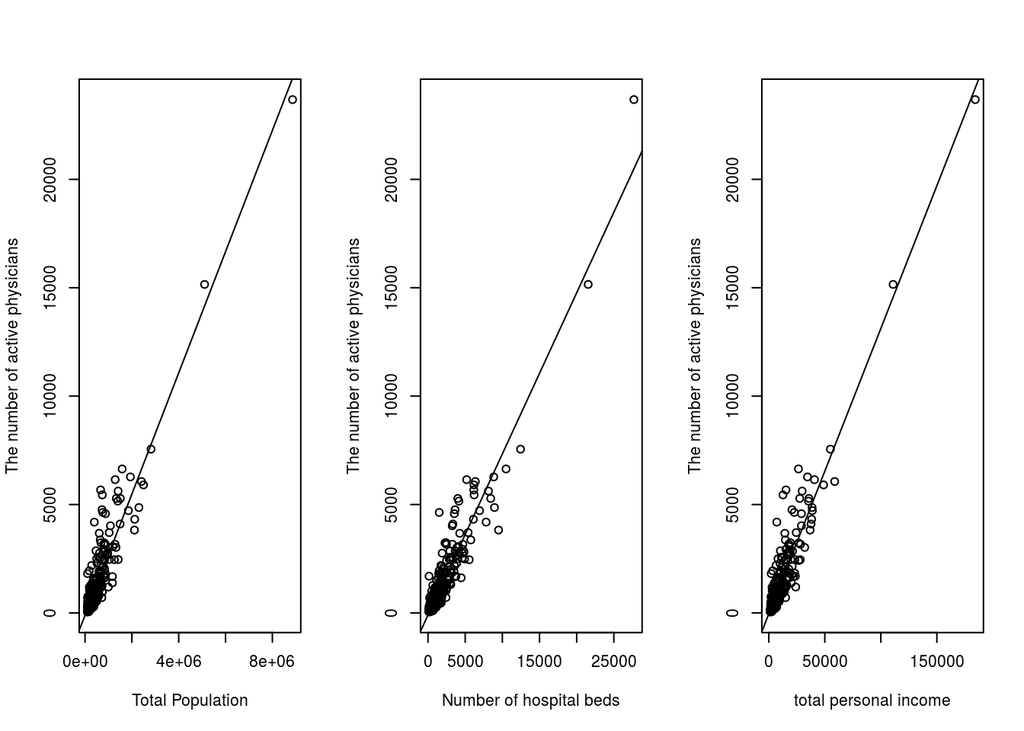

```r
par(mfrow=c(1,3))
plot(X1,Y,xlab="Total Population",ylab="The number of active physicians")
abline(f31)
plot(X2,Y,xlab="Number of hospital beds",ylab="The number of active physicians")
abline(f32)
plot(X3,Y,xlab="total personal income",ylab="The number of active physicians")
abline(f33)
```

### c) ### _Solution: Number of Hospital beds gives the smallest MSE. I would use this variable since it has the lowest MSE.

```r
n=dim(CDI)[1]
MSE1=sum(f31$residuals^2)/(n-2)
MSE2=sum(f32$residuals^2)/(n-2)
MSE3=sum(f33$residuals^2)/(n-2)
cbind(MSE1,MSE2,MSE3)
```

```
##          MSE1     MSE2     MSE3
## [1,] 372203.5 310191.9 324539.4
```

Problem 4 Refer to the CDI data set. Use the number of active physicians as Y and total personal income as X. Select 1,000 random samples of 400 observations, fit the regression model and record β0 and β1 for each selected sample. Calculate the mean and variance of β0 and β1 based on the 1,000 different regression line and compare against the regression model in question 3 part a. (20 points)

```r
dat<-data.frame(cbind(X3,Y))
prg3<-function(dat){
  n=dim(dat)[1]
  out<-data.frame(matrix(0,nrow=1000,ncol=2))
  for(i in 1:1000){
    ind=sample(1:n,400)
    dat1=dat[ind,]
    f<-lm(Y~X3,data=dat1)
    out[i,]<-c(f$coefficients)
    }
  dimnames(out)[[2]]<-c("b0","b1")
  out
}
set.seed(123)
out3=prg3(dat)
apply(out3,2,mean)
```

```
##          b0          b1
## -49.1226634   0.1317886
```

```r
apply(out3,2,var)
```

```
##           b0           b1
## 7.590102e+01 1.348196e-06
```

```r
f33$coefficients
```

```
## (Intercept)          X3
## -48.3948489   0.1317012
```